# Differential Expression Analysis of genes in kidney fibrosis

Author

Max Klemp

**Transcriptomics** deals with the identification and quantification of mRNA (i.e., transcribed genes) in an organism. The following analysis is an exemplary investigation of the genes that might or might not be differentially expressed between orhanisms with and without the condition of **kidney fibrosis.** The data used in the subsequent analyses is available [here](https://www.ncbi.nlm.nih.gov/geo/download/?acc=GSE85209) and is described in the publication by Gerarduzzi and colleagues (Gerarduzzi et al. 2017). It consists of mRNA samples from 14 mice. The mice were either of a *wildtype* genotype or a *transgenic* genotype with overexpression of Secreted Modular Calcium-Binding Protein 2 (SMOC2). They either belonged to the *normal* or to the *fibrosis* condition.

The main analysis in this notebook is performed using the `DESeq2` package (Love, Huber, and Anders 2014) from the `Bioconductor` project (Huber et al. 2015). This package encompasses some useful tools that are usually utilized for differential expression analysis, such as fitting a **Negative Binomial Distribution** to the data or performing certain transformations, **Cluster Analysis** and **Principal Component Analysis**. We could also apply all of these methods manually, but `DESeq2` provides some tailored functions for the specific data format that we are using and also equips us with a workflow for transcriptomics analysis.

## 1 Data import

As a first step, we are preparing our data for analysis. The separate data files were downloaded from the repository and merged together. `DESeq2` requires a certain representation of the data:

- one dataframe containing the meta data, i.e. information about experimental conditions and samples, which we will assign to `df_meta`
- one dataframe containing the number of reads identified per gene per sample, with the genes representing rows and samples representing columns, which we will assign to `df_transcripts`

**Tidy data**

This representation of the count data (variables/genes in rows, observations/samples in columns) does not correspond to the **tidy data** format, commonly used in statistical analysis. For this format, we would have to transpose the matrix and pivot the dataframe so that the indicators of conditions, which currently are contained in the column names, would become individual columns.

The meta data dataframe as well as the first rows from the count data frame are displayed below.

**Count matrix**

|  | count_SMOC2_normal_1 | count_SMOC2_normal_3 | count_SMOC2_normal_4 | count_SMOC2_fibrosis_1 | count_SMOC2_fibrosis_2 | count_SMOC2_fibrosis_3 | count_SMOC2_fibrosis_4 | count_WT_normal_1 | count_WT_normal_2 | count_WT_normal_3 | count_WT_fibrosis_1 | count_WT_fibrosis_2 | count_WT_fibrosis_3 | count_WT_fibrosis_4 |
| --- | --- | --- | --- | --- | --- | --- | --- | --- | --- | --- | --- | --- | --- | --- |
| ENSMUSG00000000001 | 1959 | 1868 | 2226 | 4508 | 3627 | 3042 | 3137 | 2751 | 2254 | 3310 | 4190 | 3938 | 3568 | 3708 |
| ENSMUSG00000000003 | 0 | 0 | 0 | 0 | 0 | 0 | 0 | 0 | 0 | 0 | 0 | 0 | 0 | 0 |
| ENSMUSG00000000028 | 31 | 44 | 45 | 163 | 160 | 171 | 147 | 36 | 48 | 71 | 154 | 128 | 162 | 118 |
| ENSMUSG00000000031 | 1 | 3 | 1 | 634 | 174 | 48 | 20 | 2 | 4 | 6 | 521 | 9 | 22 | 5 |
| ENSMUSG00000000037 | 5 | 7 | 9 | 21 | 28 | 29 | 22 | 11 | 12 | 13 | 48 | 32 | 35 | 33 |
| ENSMUSG00000000049 | 0 | 1 | 1 | 5 | 6 | 3 | 14 | 6 | 0 | 0 | 6 | 5 | 3 | 6 |

**Metadata**

|  | genotype | condition |
| --- | --- | --- |
| count_SMOC2_normal_1 | SMOC2 | normal |
| count_SMOC2_normal_3 | SMOC2 | normal |
| count_SMOC2_normal_4 | SMOC2 | normal |
| count_SMOC2_fibrosis_1 | SMOC2 | fibrosis |
| count_SMOC2_fibrosis_2 | SMOC2 | fibrosis |
| count_SMOC2_fibrosis_3 | SMOC2 | fibrosis |
| count_SMOC2_fibrosis_4 | SMOC2 | fibrosis |
| count_WT_normal_1 | WT | normal |
| count_WT_normal_2 | WT | normal |
| count_WT_normal_3 | WT | normal |
| count_WT_fibrosis_1 | WT | fibrosis |
| count_WT_fibrosis_2 | WT | fibrosis |
| count_WT_fibrosis_3 | WT | fibrosis |
| count_WT_fibrosis_4 | WT | fibrosis |

### 1.1 Creating DESeq2 object

The `DESeq2` package provides functions for exploratory data analysis and quality control, differential expression analysis and subsequent visualizations. At the heart of all these functionalities lies the `DESeqDataSet` object, which is created from the raw counts and the metadata. It is created by calling the `DESeqDataSetFromMatrix()` function using the two dataframes we created above. Next to these two dataframes, it also takes a `design` argument that accepts a formula. This formula specifies the model that we want to use for the analysis. In this case, we want to compare the normal and fibrosis conditions so we pass `~ condition` to the `design` argument. The `~` operator indicates that the counts are modelled as a function of the formular that follows the operator. We store the data object in `deseq_data`.

```r
deseq_data <- DESeqDataSetFromMatrix(df_transcripts, df_meta, design = ~ condition)
```

## 2 Exploratory data analysis

Before performing the actual **Differential Expression Analysis**, we will conduct some exploratory data analysis based on *Unsupervised Learning* techniques in order to get a better understanding of the data and to check for potential outliers. We will perform **Hierarchical Clustering** and **Principal Component Analysis**, but before applying these algorithms, we have to apply two steps of pre-processing to our data.

### 2.1 Normalizing raw counts

The raw counts in our data might be biased by differences in sequencing depth between samples. For example, if one sample has a higher sequencing depth (i.e. more reads) than another, then the counts for that sample will be higher, even if the gene expression profile is the same. This is problematic for differential expression analysis, since it might confound the comparison of gene expression profiles across samples.

Therefore, we will normalize the raw counts to account for differences in sequencing depth between samples. `DESeq2` allows calculation of size factors which scale the raw counts for normalization. We use the `estimateSizeFactors()` function for this and the normalized values are stored back in our `deseq_data` object.

**Normalization in DESeq2**

When performing **Differential Expression Analysis** using `DESeq2()`, as we will later, the normalization is done automatically. However, since we want to perform some exploratory data analysis, including hierarchical clustering and PCA, we will normalize the counts here.

```r
# Determine the size factors to use for normalization
deseq_data <- estimateSizeFactors(deseq_data)
```

### 2.2 Variance Stabilizing Transformation

The second necessity arises from a statistical property that is common for count data. For the expression rates of genes, the variance is often dependent on the mean (i.e. genes with higher expression will tend to have higher absolute variance). This is problematic for methods like clustering and PCA, since they assume homoscedasticity (similarity of variance) across dimensions (in this case, genes). A transformation that can alleviate these problems is the **Variance Stabilizing Transformation (VST)**. The VST transforms the data so that the variance is approximately constant across the mean. This involves fitting Negative Binomial Distributions to each gene and estimating the respective mean dispersion parameters of these distributions (since these make up the distribution’s variance). From these, the mean-variance-relationship is estimated from all genes. The function which is then applied to the counts makes sure that the derivative of the variance with respect to the mean is approximately constant.

The VST is implemented in `DESeq2` through the `vst()` function, and we apply it here to our normalized counts.

```r
# Transform the normalized counts
vst_data <- vst(deseq_data, blind=TRUE)

# Extract the matrix of transformed counts
vst_data_matrix <- assay(vst_data)
```

### 2.3 Hierarchical clustering

To visualize the relationships between our samples, we will perform hierarchical clustering in order to identify clusters of samples. Ideally, we would like to see our samples cluster into groups resembling the actual experimental conditions. After having transformed the data using VST, we can proceed with the following steps:

1. We first compute the correlation matrix for all samples based on the transformed counts.
2. Next, we plot a heatmap of the correlation matrix, with samples grouped by their condition. This allows us to see if samples from the same condition cluster together, which would indicate that the condition has a strong effect on the gene expression profiles.

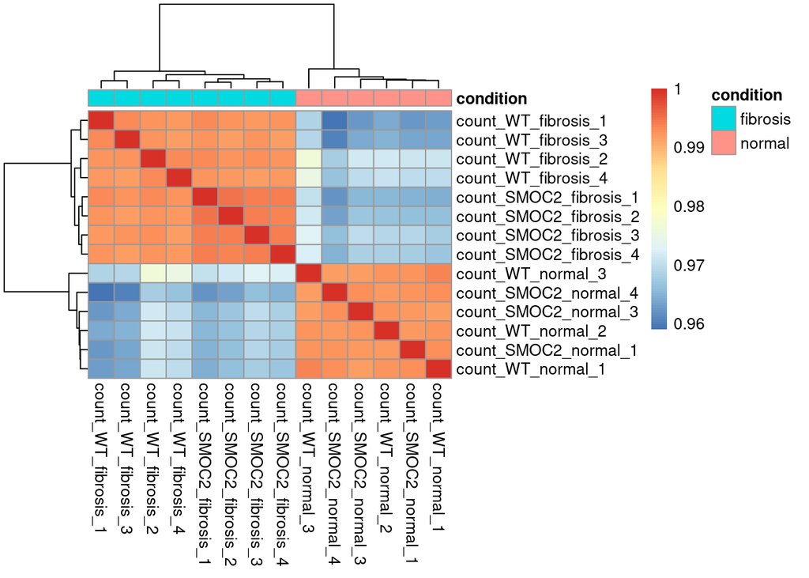

```r
# Compute the correlation values between samples
vst_cor_matrix <- cor(vst_data_matrix)

# Plot the heatmap
pheatmap(vst_cor_matrix, annotation = dplyr::select(df_meta, condition))
```

### 2.4 Principal component analysis

Next, we try to identify potential outlier samples in our data visually. Since the dataset contains roughly 47000 genes (i.e. variables), we cannot visualize the dataset easily. However, we can make use of the fact that expression rates are correlated for a lot of genes, meaning that not every dimension actually adds information. We can try to reduce the dimensionality of our dataset by combining the information of multiple dimensions into one. One such dimensionality reduction technique is **Principal Components Analysis**, a technique using linear combinations of the original matrix in order to create new dimensions that are orthogonal to each other and that explain the most variance in the data. The first principal component explains the most variance, the second principal component explains the most variance of the remaining variance, and so on.

We use the built-in function from `DESeq2` to visualize the first two components of our data in order to (1) identify potential outliers and (2) again verify if our experimental conditions cluster together in this dimensionality-reduced vector space. This can be done using the `plotPCA()` function. We additionally color the points by condition.

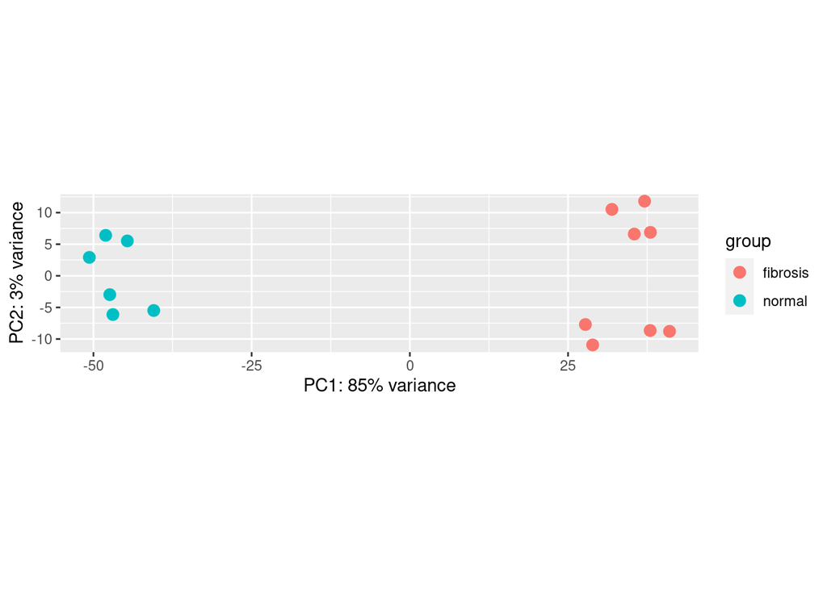

```r
# Plot the PCA of PC1 and PC2
plotPCA(vst_data, intgroup="condition")
```

**Performing PCA with low sample size**

As a general note: if the number of observations $n$ is lower than the number of variables $p$, we can at most extract $n$ components. Given that we have roughly 47000 variables in this dataset, for a proper Principal Components Analysis, we might want to compare different dimensionalities of the data, higher than 14. Additionally, having only 14 observations poses the risk of overfitting, so the validity of a PCA could be questioned. However, since we do not pass information about the condition to the PCA, seeing a clear separation of the samples by condition increases our trust in the results of the PCA. Also, the low sample size might become a more severe problem if we were to choose a higher dimensionality of the vector space and wanted to disinguish between, let’s say, using 10 or 50 components. Using only 2 components for exploratory data analysis and quality control, however, should be sufficient.

**Both hierarchical clustering and PCA could also be performed independently from `DESeq2()` and you might want to try this out in order to be more flexible or to explore more features of the clusters and components. We stick to the built-in functions for now for compliance with the workflow.**

## 3 Differential Expression Analysis

After having performed exploratory data analysis and some sanity checks on our data, we are ready to proceed with **Differential Expression Analysis**. The goal is to identify genes that are **significantly** differentially expressed between conditions. We will discuss the statistical approach to this in a moment, but first we have to revisit the mean-variance-relationship and dispersion again shortly.

`DESeq2` models the distribution of expression rates for each gene as a **Negative Binomial Distribution**. This is a probability distribution similar to the **Poisson Distribution** allowing for more dispersion. This manifests in the parameterization in form of the dispersion parameter, which is commonly denoted as $\alpha$ and estimated next to the mean. The variance of the distribution is a consequence of the mean and the dispersion. Estimating the dispersion of a Negative Binomial Distribution is not trivial and, therefore, caution has to be taken when estimating this parameter from a sample, especially if the sample is potentially small, like in our case for each individual gene. Since this is a common challenge in transcriptomics, `DESeq2` contains a way to handle this challenge. First, we initialize the `DESeq` obejct which we will utilize for **Differential Expression Analysis**:

```r
# Run the DESeq2 analysis
deseq_analysis <- DESeq(deseq_data)
```

### 3.1 Estimating dispersion

The dispersion parameter of the negative binomial distribution is estimated for each gene. However, as stated above, due to small sample sizes, we might underestimate dispersion if we estimate it based on only 14 observations. If dispersion is underestimated for certain genes, then the variance of the counts for those genes will be underestimated. This will lead to an increase in the false positive rate for those genes, i.e. genes will be incorrectly called as differentially expressed.

Therefore, `DESeq2` uses information from all genes to model the mean-dispersion-relationship. This is done by fitting a generalized linear model (GLM) to the data, with the dispersion as the response variable and the mean as the predictor variable. The result of this model can be shown using the `plotDispEsts()` function:

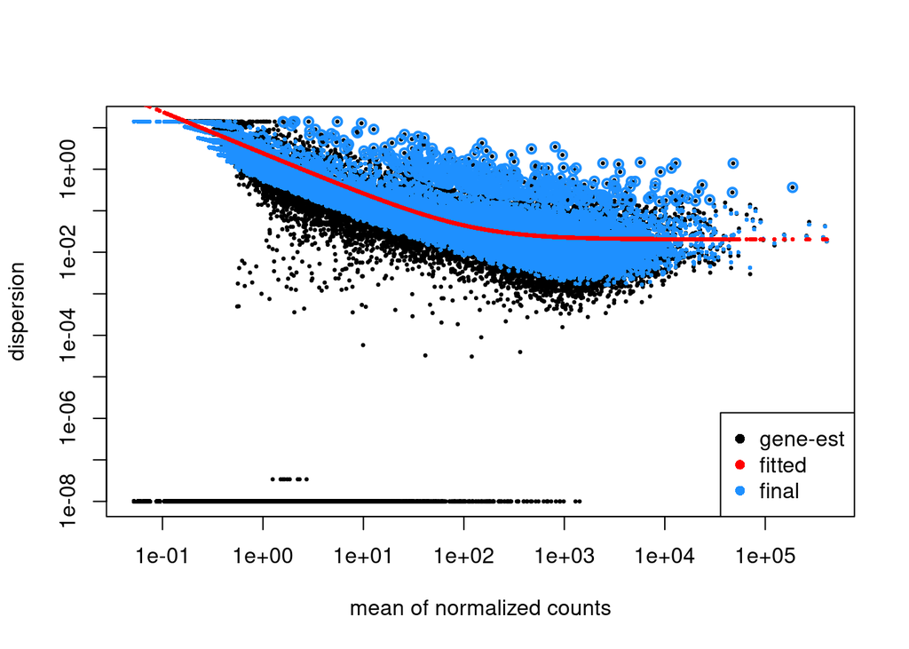

```r
plotDispEsts(deseq_analysis)
```

The black dots are the original gene-wise dispersion estimates, and the red line is the fitted GLM. The dispersion estimates are shrunk towards the fitted line in order to avoid underestimation of dispersion due to small sample sizes. These more accurate, shrunken dispersion estimates are used to model the counts in the differential expression analysis. Extremely high dispersion estimates are not shrunken because it is assumed that certain genes show a high degree of biological variability and therefore these dispersion estimates might be accurate. The degree to which shrinkage affects the dispersion estimates depends on the distance from the curve and the sample size. Larger sample sizes would enable a more accurate estimation of dispersion and would therefore be less affected by shrinkage.

If the plot shown above shows data that doesn’t follow the curve or dispersions that do not decrease with increasing mean, this would indicate a violation of the main assumptions about the data and could be a sign of outlier samples or contamination.

### 3.2 Investigate model

The `DESeq2` analysis uses a **Generalized Linear Model (GLM)** to model the counts. The model is generalized with respect to the assumed distribution of the target variable, which in this case, as stated before, is a Negative Binomial Distribution.

The GLM is used to model the counts as a function of the condition, and the Differential Expression Analysis is performed by comparing the coefficients of the GLM for each gene.

```r
# Extract the coefficients of the GLM
deseq_res <- results(deseq_analysis, contrast = c("condition", "fibrosis", "normal"), alpha = 0.05)

deseq_res %>%
  head() %>%
  kable()
```

|  | baseMean | log2FoldChange | lfcSE | stat | pvalue | padj |
| --- | --- | --- | --- | --- | --- | --- |
| ENSMUSG00000000001 | 3037.402514 | 0.1838096 | 0.0870659 | 2.111156 | 0.0347589 | 0.0626408 |
| ENSMUSG00000000003 | 0.000000 | NA | NA | NA | NA | NA |
| ENSMUSG00000000028 | 97.259742 | 1.2611277 | 0.1450924 | 8.691895 | 0.0000000 | 0.0000000 |
| ENSMUSG00000000031 | 83.954936 | 5.4717087 | 1.0068881 | 5.434277 | 0.0000001 | 0.0000002 |
| ENSMUSG00000000037 | 20.125501 | 1.2604582 | 0.2893384 | 4.356346 | 0.0000132 | 0.0000385 |
| ENSMUSG00000000049 | 3.693749 | 1.7867594 | 0.7777090 | 2.297465 | 0.0215922 | 0.0406292 |

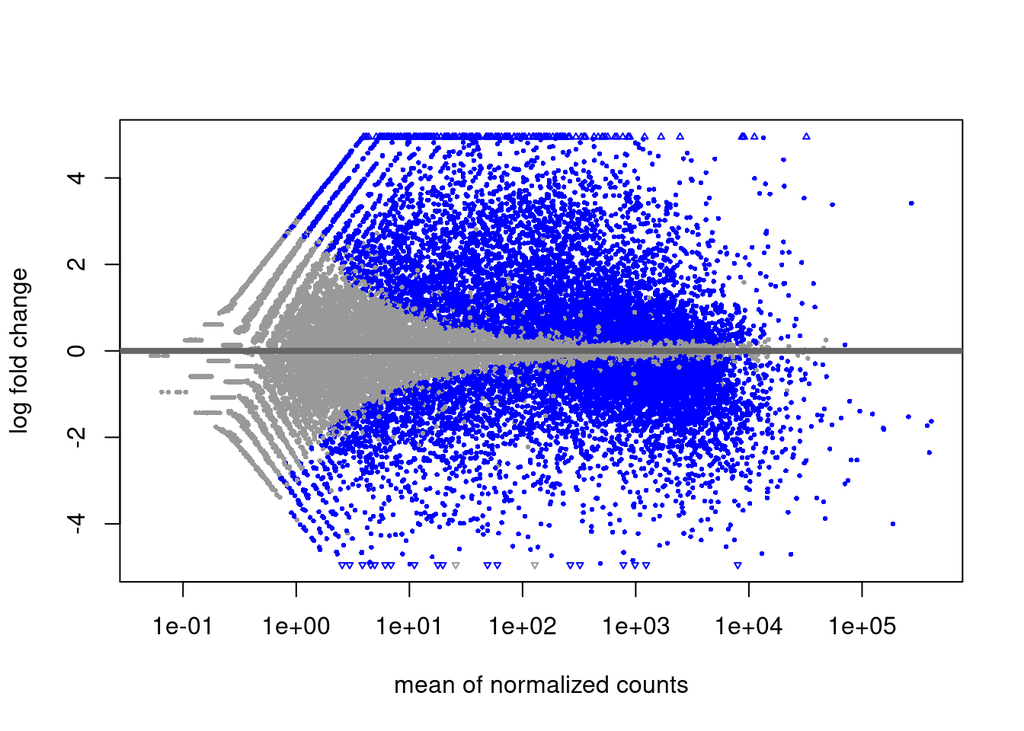

```r
# Plot the coefficients
plotMA(deseq_res)
```

### 3.3 Log2-fold change shrinkage

The **log2-fold change (LFC)** is the difference in the log2-transformed normalized counts between two conditions. It is calculated by taking the log2 of the ratio of the normalized counts between the two conditions. This is done for each gene, and the result is a vector of log2-fold changes, one for each gene. However, the plot above indicates large LFC for genes with low means, i.e. low expression. It is unlikely that these low-mean genes show such high LFC, and these large LFC are likely to be due to noise in the data. Therefore, we will apply LFC shrinkage to the data, which will shrink the log2-fold changes towards zero for genes with low means, similarly to what we did before with dispersions. This approach will create an alternative results object. We will use the **Adaptive SHrinkage (ASH)** method (Stephens 2016) for this.

After shrinking the coefficients, we again plot them and see that the large LFC for genes with low means have been shrunk towards zero.

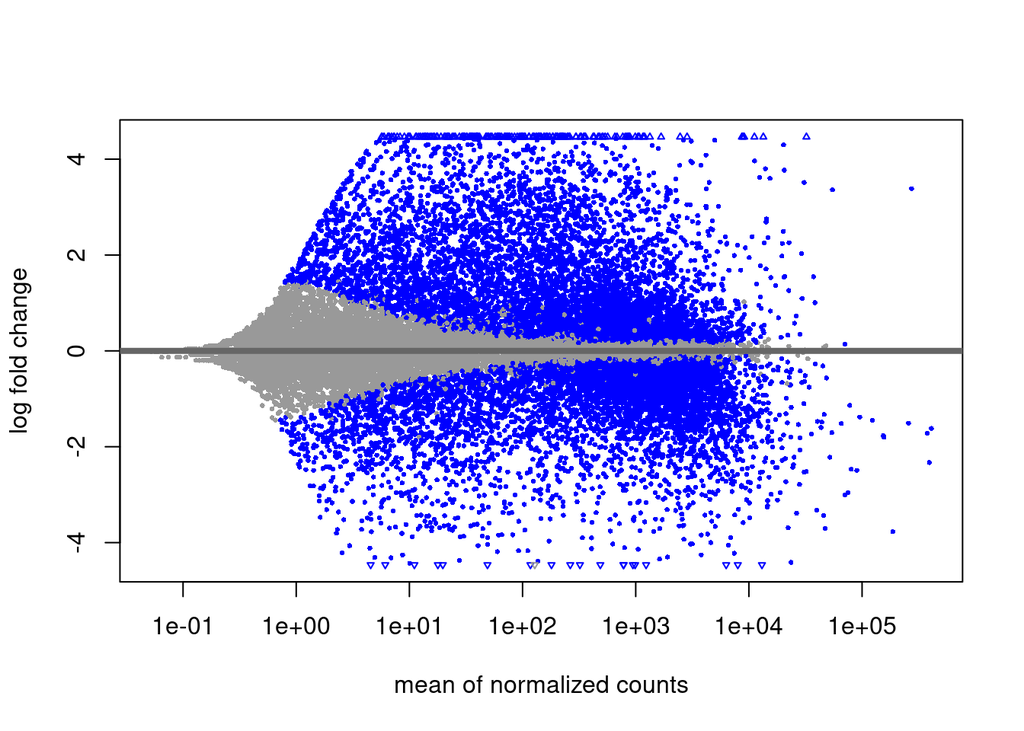

```r
# perform LFC shrinkage
deseq_resLFC <- lfcShrink(deseq_analysis, alpha = 0.05, res = deseq_res, contrast = c("condition", "fibrosis", "normal"), type = "ashr")

# Plot the coefficients
plotMA(deseq_resLFC)
```

### 3.4 Testing for differential expression

Now we want to investigate which genes can actually be considered to be differentially expressed between the two conditions. For this, we will use the Wald test, which is a statistical test that is used to test the significance of the coefficients of a GLM. It basically divides a coefficient by its standard error, indicating our confidence in the coefficient. Alternative methods for statistical inference in GLMs are available, such as Likelihood-Ratio-Tests. In this case, we are testing the significance of the coefficients of the GLM that was used to model the counts. The Wald test is performed for each gene, and the result is a vector of p-values, one for each gene.

A well-recognized challenge in Null-Hypothesis-Significance-Testing is the risk of false positives, which is a direct consequence of our choice of the significance level. At a significance level of 5%, we have a 5% probability of falsely rejecting the null hypothesis, i.e. of calling a gene differentially expressed when it is not. Considering the large number of genes we are testing, this is a problem. For our example of roughly 47000 genes, we would flag 2350 genes as being differentially expressed, just by chance. In order to account for this multiple testing, we have to apply some correction method. A commonly used method is the Benjamini-Hochberg procedure (Benjamini and Hochberg 1995).

After correction, we can examine the results by calling the `summary()` function on our `results` object (the one with shrunken coefficients). Because the number of genes with p-values below the threshold is overwhelming, this function gives us a quick indication of how many genes are significantly up- and how many are significantly down-regulated as well as the number of genes that were not considered for analysis because they were considered outliers or had too low counts.

```r
summary(deseq_resLFC)
```

```
out of 31546 with nonzero total read count
adjusted p-value < 0.05
LFC > 0 (up)       : 7092, 22%
LFC < 0 (down)     : 6457, 20%
outliers [1]       : 15, 0.048%
low counts [2]     : 6546, 21%
(mean count < 0)
[1] see 'cooksCutoff' argument of ?results
[2] see 'independentFiltering' argument of ?results
```

We can now filter our dataframe for the genes that are significantly differentially expressed, store them in a dataframe and look at the first few rows.

```r
# Save results as a data frame
df_res <- as.data.frame(deseq_resLFC)

# Subset the results to only return the significant genes with p-adjusted values less than 0.05
df_res_sig <- filter(df_res, padj < .05)

df_res_sig %>%
  head() %>%
  kable()
```

|  | baseMean | log2FoldChange | lfcSE | pvalue | padj |
| --- | --- | --- | --- | --- | --- |
| ENSMUSG00000000028 | 97.259742 | 1.2375076 | 0.1457175 | 0.0000000 | 0.0000000 |
| ENSMUSG00000000031 | 83.954936 | 4.3871277 | 0.9493897 | 0.0000001 | 0.0000002 |
| ENSMUSG00000000037 | 20.125501 | 1.1617517 | 0.2973328 | 0.0000132 | 0.0000385 |
| ENSMUSG00000000049 | 3.693749 | 1.1537864 | 0.7737977 | 0.0215922 | 0.0406292 |
| ENSMUSG00000000056 | 1114.570242 | -0.7053935 | 0.1053419 | 0.0000000 | 0.0000000 |
| ENSMUSG00000000078 | 3613.023416 | 2.4438509 | 0.1251058 | 0.0000000 | 0.0000000 |

### 3.5 Identify differentially expressed genes

Lastly, it would be interesting to see which genes are actually differentially expressed. For this, we can load the `annotables` package and use the `grcm38` dataset containing information about a multitude of genes:

```r
library(annotables)
# browse the annotation dataset
grcm38 %>%
  head() %>%
  kable()
```

| ensgene | entrez | symbol | chr | start | end | strand | biotype | description |
| --- | --- | --- | --- | --- | --- | --- | --- | --- |
| ENSMUSG00000000001 | 14679 | Gnai3 | 3 | 108014596 | 108053462 | -1 | protein_coding | guanine nucleotide binding protein (G protein), alpha inhibiting 3 |
| ENSMUSG00000000003 | 54192 | Pbsn | X | 76881507 | 76897229 | -1 | protein_coding | probasin |
| ENSMUSG00000000028 | 12544 | Cdc45 | 16 | 18599197 | 18630737 | -1 | protein_coding | cell division cycle 45 |
| ENSMUSG00000000031 | 14955 | H19 | 7 | 142129262 | 142131886 | -1 | lncRNA | H19, imprinted maternally expressed transcript |
| ENSMUSG00000000037 | 107815 | Scml2 | X | 159865521 | 160041209 | 1 | protein_coding | Scm polycomb group protein like 2 |
| ENSMUSG00000000049 | 11818 | Apoh | 11 | 108234180 | 108305222 | 1 | protein_coding | apolipoprotein H |

We can map the names and descriptions of the genes to their *Ensembl ID* (which is the identifier used in our dataset). Lastly, we can sort our dataframe in order to output the top 5 genes that are significantly upregulated in the fibrosis condition. Doing this, we find **Interleukin 36A** being the gene with the highest upregulation in the fibrosis condition.

```r
# join the results dataframe with the annotation dataset
df_res_full <- df_res_sig %>%
  rownames_to_column(var = "ensgene") %>%
  left_join( y = grcm38[, c("ensgene", "symbol", "description")], by = "ensgene")

df_res_full %>%
  arrange(desc(log2FoldChange)) %>%
  head() %>%
  kable()
```

| ensgene | baseMean | log2FoldChange | lfcSE | pvalue | padj | symbol | description |
| --- | --- | --- | --- | --- | --- | --- | --- |
| ENSMUSG00000026984 | 259.83658 | 10.295284 | 0.9006283 | 0 | 0 | Il36a | interleukin 36A |
| ENSMUSG00000036198 | 350.57745 | 8.583850 | 0.6083101 | 0 | 0 | Arhgap36 | Rho GTPase activating protein 36 |
| ENSMUSG00000035373 | 113.91390 | 7.979063 | 0.8704935 | 0 | 0 | Ccl7 | chemokine (C-C motif) ligand 7 |
| ENSMUSG00000050635 | 98.55281 | 7.529468 | 0.9751151 | 0 | 0 | Sprr2f | small proline-rich protein 2F |
| ENSMUSG00000037428 | 145.81718 | 7.079866 | 0.9933134 | 0 | 0 | Vgf | VGF nerve growth factor inducible |
| ENSMUSG00000001131 | 1676.05117 | 7.042044 | 0.3988681 | 0 | 0 | Timp1 | tissue inhibitor of metalloproteinase 1 |

We could now investigate our results for potential mechanisms that might explain the up- or downregulation of certain genes. We could also look up previous evidence in order to see whether our findings have been reported before.

## References

Benjamini, Yoav, and Yosef Hochberg. 1995. “Controlling the False Discovery Rate: A Practical and Powerful Approach to Multiple Testing.” *Journal of the Royal Statistical Society: Series B (Methodological)* 57 (1): 289–300. https://doi.org/10.1111/j.2517-6161.1995.tb02031.x.

Gerarduzzi, Casimiro, Ramya K. Kumar, Priyanka Trivedi, Amrendra K. Ajay, Ashwin Iyer, Sarah Boswell, John N. Hutchinson, Sushrut S. Waikar, and Vishal S. Vaidya. 2017. “Silencing SMOC2 Ameliorates Kidney Fibrosis by Inhibiting Fibroblast to Myofibroblast Transformation.” *JCI Insight* 2 (8). https://doi.org/10.1172/jci.insight.90299.

Huber, W., V. J. Carey, R. Gentleman, S. Anders, M. Carlson, B. S. Carvalho, H. C. Bravo, et al. 2015. “Orchestrating High-Throughput Genomic Analysis with Bioconductor.” *Nature Methods* 12 (2): 115–21. http://www.nature.com/nmeth/journal/v12/n2/full/nmeth.3252.html.

Love, Michael I, Wolfgang Huber, and Simon Anders. 2014. “Moderated Estimation of Fold Change and Dispersion for RNA-Seq Data with DESeq2.” *Genome Biology* 15 (12). https://doi.org/10.1186/s13059-014-0550-8.

Stephens, Matthew. 2016. “False Discovery Rates: A New Deal.” *Biostatistics*, October, kxw041. https://doi.org/10.1093/biostatistics/kxw041.